# Convolution performance and intuition

Date: May 29, 2020

Table of contents:

- Tensor operations performance
- VGG16 performance
- General convolution performance

In this post, I hope to explain the effectiveness and efficiency of convolution layers. Why do we do them? What's the intuition and how can we improve?

## Tensor operations performance

Before all of this, we need to have a way to actually test our performance and test out our predictions. Let's import several stuff first:

```python
import torch
import torch.nn as nn
import torch.nn.functional as F
import numpy as np
import matplotlib.pyplot as plt
import time
import gc
```

Let's apply a function over increasingly larger tensors and time those operations. Timing these things are pretty complicated and involved, and we sort of have to be memory-aware here, even in Python, and carefully deallocate large tensors and tells Python's garbage collector to collect them:

```python
def timeFunction(sizes, function: callable, use_gpu=False):
    times = []
    # primes the computer so that this one absorbes all the overhead
    a = torch.rand(50, 1000, 1000);
    if use_gpu: a = a.cuda()
    del a; gc.collect()
    for size in sizes:
        a = torch.rand(size, 1000, 1000)
        if use_gpu: a = a.cuda()
        beginTime = time.time()
        b=function(a)
        times.append(time.time()-beginTime)
        del a; del b; gc.collect()
    return times
```

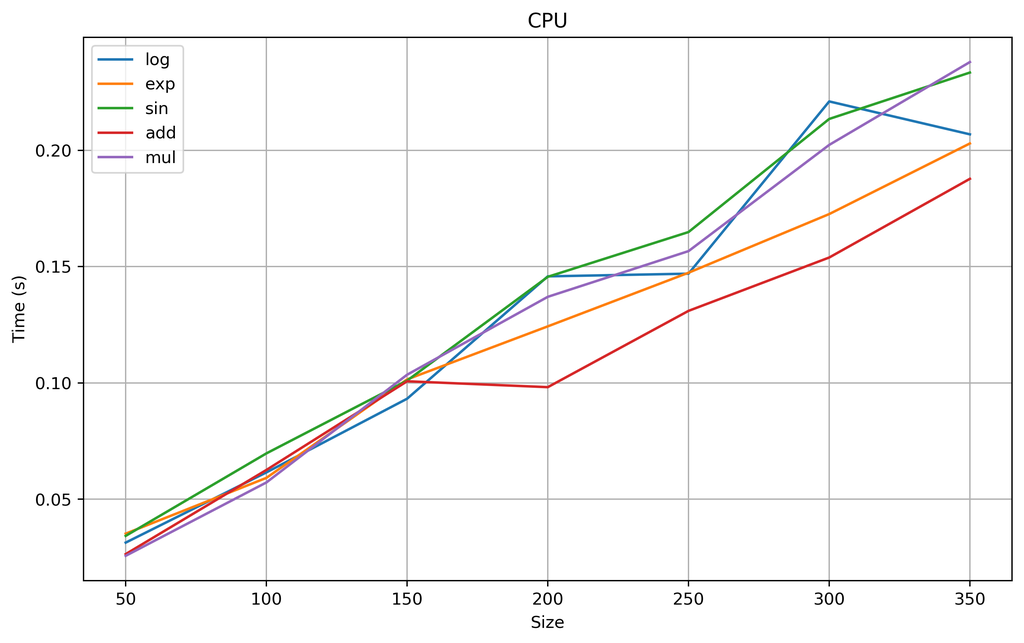

```python
sizes = (np.array(range(7))+1)*50
plt.figure(num=None, figsize=(10, 6), dpi=350)
plt.plot(sizes, timeFunction(sizes, lambda x: torch.log(x)))
plt.plot(sizes, timeFunction(sizes, lambda x: torch.exp(x)))
plt.plot(sizes, timeFunction(sizes, lambda x: torch.sin(x)))
plt.plot(sizes, timeFunction(sizes, lambda x: x+5))
plt.plot(sizes, timeFunction(sizes, lambda x: x*3))
plt.legend(["log", "exp", "sin", "add", "mul"])
plt.grid(True); plt.xlabel("Size"); plt.ylabel("Time (s)"); plt.title("CPU"); plt.show(); pass
```

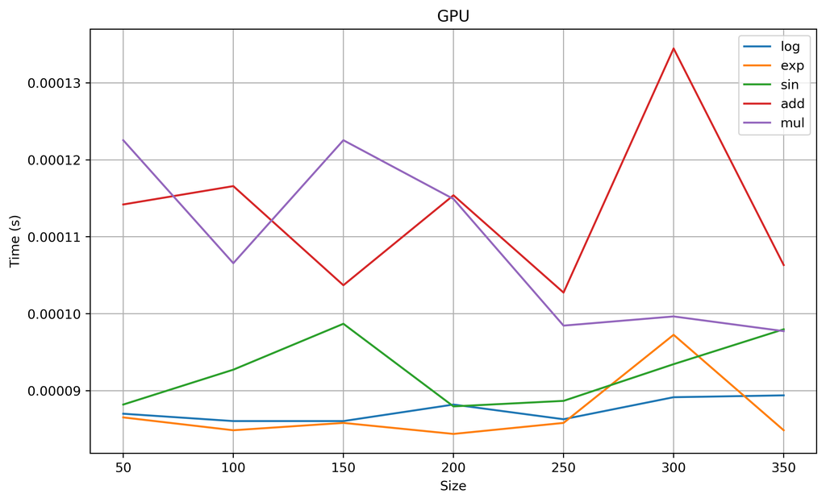

```python
sizes = (np.array(range(7))+1)*50
plt.figure(num=None, figsize=(10, 6), dpi=350)
plt.plot(sizes, timeFunction(sizes, lambda x: torch.log(x), True))
plt.plot(sizes, timeFunction(sizes, lambda x: torch.exp(x), True))
plt.plot(sizes, timeFunction(sizes, lambda x: torch.sin(x), True))
plt.plot(sizes, timeFunction(sizes, lambda x: x+5, True))
plt.plot(sizes, timeFunction(sizes, lambda x: x*3, True))
plt.legend(["log", "exp", "sin", "add", "mul"])
plt.grid(True); plt.xlabel("Size"); plt.ylabel("Time (s)"); plt.title("GPU"); plt.show(); pass
```

Okay, so the CPU results looks reasonable enough. The bigger the tensor, the longer it takes. Interestingly, complex operations seem to run as fast as simple ones. The GPU results are pretty much all over the place, and doesn't seem to follow any trends at all. It's also pretty mind blowing that the GPU is $\frac{0.25}{0.00013}=1923$ times faster than the CPU. That's some serious speed up right there.

```python
# (a, b, c, d, e) @ (a, b, c, e, f)
def timeTensorMultiply(a=45, b=45, c=45, d=45, e=45, f=45):
    times = []
    # primes the computer so that this one absorbes all the overhead
    x = torch.rand(a, b, c, d, e); y = torch.rand(a, b, c, e, f); z = x @ y
    del x; del y; del z; gc.collect()
    # real deal
    x = torch.rand(a, b, c, d, e); y = torch.rand(a, b, c, e, f);
    beginTime = time.time(); z = x @ y; timeTaken = time.time()-beginTime
    del x; del y; del z; gc.collect()
    return timeTaken
```

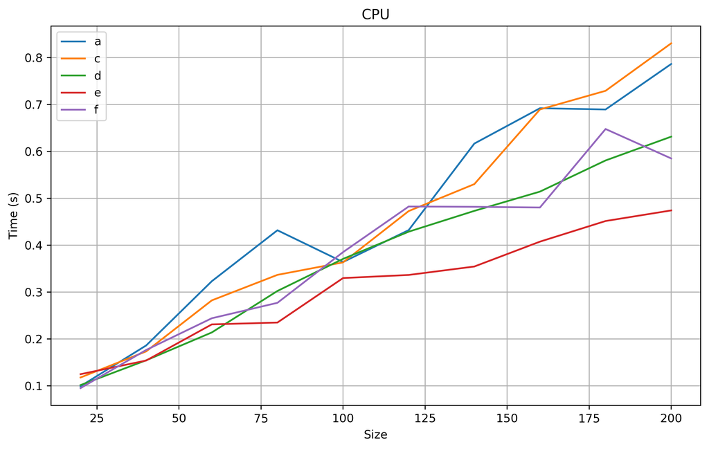

```python
sizes = (np.array(range(10))+1)*20
plt.figure(num=None, figsize=(10, 6), dpi=350)
plt.plot(sizes, [timeTensorMultiply(a=size) for size in sizes])
plt.plot(sizes, [timeTensorMultiply(c=size) for size in sizes])
plt.plot(sizes, [timeTensorMultiply(d=size) for size in sizes])
plt.plot(sizes, [timeTensorMultiply(e=size) for size in sizes])
plt.plot(sizes, [timeTensorMultiply(f=size) for size in sizes])
plt.legend(["a", "c", "d", "e", "f"])
plt.grid(True); plt.xlabel("Size"); plt.ylabel("Time (s)"); plt.title("CPU"); plt.show(); pass
```

## VGG16 performance

Let's now take the VGG16 network ([original paper](https://arxiv.org/pdf/1409.1556.pdf)), a quite badass architecture but still simple enough that we can look inside. Here's how it looks like:

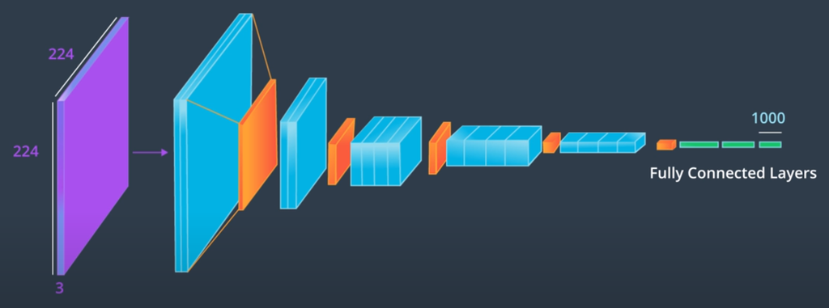

Let's now see the details of it:

```python
from torchvision import datasets, models, transforms
vgg16 = models.vgg16(pretrained=True)
vgg16
```

```
VGG(
  (features): Sequential(
    (0): Conv2d(3, 64, kernel_size=(3, 3), stride=(1, 1), padding=(1, 1))
    (1): ReLU(inplace=True)
    (2): Conv2d(64, 64, kernel_size=(3, 3), stride=(1, 1), padding=(1, 1))
    (3): ReLU(inplace=True)
    (4): MaxPool2d(kernel_size=2, stride=2, padding=0, dilation=1, ceil_mode=False)
    (5): Conv2d(64, 128, kernel_size=(3, 3), stride=(1, 1), padding=(1, 1))
    (6): ReLU(inplace=True)
    (7): Conv2d(128, 128, kernel_size=(3, 3), stride=(1, 1), padding=(1, 1))
    (8): ReLU(inplace=True)
    (9): MaxPool2d(kernel_size=2, stride=2, padding=0, dilation=1, ceil_mode=False)
    (10): Conv2d(128, 256, kernel_size=(3, 3), stride=(1, 1), padding=(1, 1))
    (11): ReLU(inplace=True)
    (12): Conv2d(256, 256, kernel_size=(3, 3), stride=(1, 1), padding=(1, 1))
    (13): ReLU(inplace=True)
    (14): Conv2d(256, 256, kernel_size=(3, 3), stride=(1, 1), padding=(1, 1))
    (15): ReLU(inplace=True)
    (16): MaxPool2d(kernel_size=2, stride=2, padding=0, dilation=1, ceil_mode=False)
    (17): Conv2d(256, 512, kernel_size=(3, 3), stride=(1, 1), padding=(1, 1))
    (18): ReLU(inplace=True)
    (19): Conv2d(512, 512, kernel_size=(3, 3), stride=(1, 1), padding=(1, 1))
    (20): ReLU(inplace=True)
    (21): Conv2d(512, 512, kernel_size=(3, 3), stride=(1, 1), padding=(1, 1))
    (22): ReLU(inplace=True)
    (23): MaxPool2d(kernel_size=2, stride=2, padding=0, dilation=1, ceil_mode=False)
    (24): Conv2d(512, 512, kernel_size=(3, 3), stride=(1, 1), padding=(1, 1))
    (25): ReLU(inplace=True)
    (26): Conv2d(512, 512, kernel_size=(3, 3), stride=(1, 1), padding=(1, 1))
    (27): ReLU(inplace=True)
    (28): Conv2d(512, 512, kernel_size=(3, 3), stride=(1, 1), padding=(1, 1))
    (29): ReLU(inplace=True)
    (30): MaxPool2d(kernel_size=2, stride=2, padding=0, dilation=1, ceil_mode=False)
  )
  (avgpool): AdaptiveAvgPool2d(output_size=(7, 7))
  (classifier): Sequential(
    (0): Linear(in_features=25088, out_features=4096, bias=True)
    (1): ReLU(inplace=True)
    (2): Dropout(p=0.5, inplace=False)
    (3): Linear(in_features=4096, out_features=4096, bias=True)
    (4): ReLU(inplace=True)
    (5): Dropout(p=0.5, inplace=False)
    (6): Linear(in_features=4096, out_features=1000, bias=True)
  )
)
```

[output not shown]

The setup for using fully connected layers:

- Input image: $(\#samples, image\_edge^2, in\_channels)$
- Output image: $(\#samples, image\_edge^2, out\_channels)$
- Transition tensor: $(image\_edge^2, in\_channels, out\_channels)$
- #params: $image\_edge^2\cdot in\_channels\cdot out\_channels$
- Calculations: $(image\_edge^2\cdot in\_channels\cdot out\_channels)$ per sample

And the setup for using convoluton layers:

- Input image: $(\#samples, image\_height, image\_width, in\_channels)$
- Output image: $(\#samples, image\_height, image\_width, out\_channels)$
- Kernel tensor: $(out\_channels, in\_channels, 3, 3)$
- #params: $out\_channels\cdot in\_channels\cdot9$
- Calculations: $9\cdot image\_edge^2\cdot in\_channels\cdot out\_channels$ per sample

So, as you can see, convolution layers calculate 9 times more than fully connected layers, just because of the fact that there are 9 elements in a 3x3 kernel. However, the number of parameters is lower by 2 orders of magnitude for the convolution layer!! And if you look more closely, the bulk parameters in a convolution layer is at the end, where the meaning extraction is happening, while there aren't much happening at the beginning layers as the idea representation is still crude there. An added bonus point is that convolution layers preserve 2d structures, where in a fully connected layer, this detail is not readily visible and exploitable by the network.

## General convolution performance

Let's see if this agrees with a bit of experimentation. `conv6()` is a function from a [previous post](http://blackbox.nn.157239n.com/conv-2) that we built from scratch, so it should be fair as we are implementing the fully connected layer ourselves too. The original `conv6()` is written for the GPU only, so we changing the transformed tensor from `torch.cuda.FloatTensor` to `torch.FloatTensor`:

```python
def conv6(imgs, kernel, stride=[1, 1], padding=[0, 0, 0, 0]):
    sY, sX = (stride, stride) if type(stride) == int else stride
    if type(padding) == int: padding = [padding] * 4
    imgs = imgs.permute(0, 2, 3, 1)
    kernel = kernel.permute(2, 3, 1, 0)
    ksY, ksX, inChannels, outChannels = kernel.shape
    pY, pX = ksY - 1, ksX - 1 # internal padding, to be used at different places
    samples, height, width, _ = imgs.shape
    transformed = torch.FloatTensor(samples, height-pY, width-pX, outChannels).zero_()
    for yK in range(ksY): # yKernel
        for xK in range(ksX): # xKernel
            transformed += (imgs @ kernel[yK, xK])[:, yK:height-pY+yK, xK:width-pX+xK, :]
    return nn.ConstantPad2d(padding, 0)(transformed[:, ::sY, ::sX, :].permute(0, 3, 1, 2))
```

We're still gonna try out the built in convolution function too, to make sure they're not using any magic that don't comply with our analysis:

```python
convTimes = []
builtinConvTimes = []
fcTimes = []
channels, edge = 64, 300
for kernelSize in range(1, 10):
    img = torch.rand(1, channels, edge, edge)
    kernel = torch.rand(channels+1, channels, kernelSize, kernelSize)
    fc = torch.rand(edge**2, channels, channels+1)

    conv6(img, kernel, padding=1).shape # priming
    beginTime = time.time()
    conv6(img, kernel, padding=1).shape
    convTimes.append(time.time() - beginTime)

    F.conv2d(img, kernel, padding=1).shape # priming
    beginTime = time.time()
    F.conv2d(img, kernel, padding=1).shape
    builtinConvTimes.append(time.time() - beginTime)

    tImg = img.view(1, channels, edge**2).permute(0, 2, 1).unsqueeze(2)
    (tImg @ fc).squeeze() # priming
    beginTime = time.time()
    (tImg @ fc).squeeze()
    fcTimes.append(time.time() - beginTime)
```

```python
convTimes = np.array(convTimes)
builtinConvTimes = np.array(builtinConvTimes)
fcTimes = np.array(fcTimes)
```

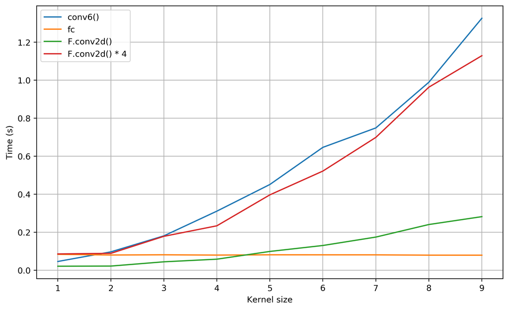

```python
plt.figure(num=None, figsize=(10, 6), dpi=350)
plt.plot(range(1, 10), convTimes)
plt.plot(range(1, 10), fcTimes)
plt.plot(range(1, 10), builtinConvTimes)
plt.plot(range(1, 10), builtinConvTimes*4)
plt.legend(["conv6()", "fc", "F.conv2d()", "F.conv2d() * 4"])
plt.grid(True); plt.xlabel("Kernel size"); plt.ylabel("Time (s)"); pass
```

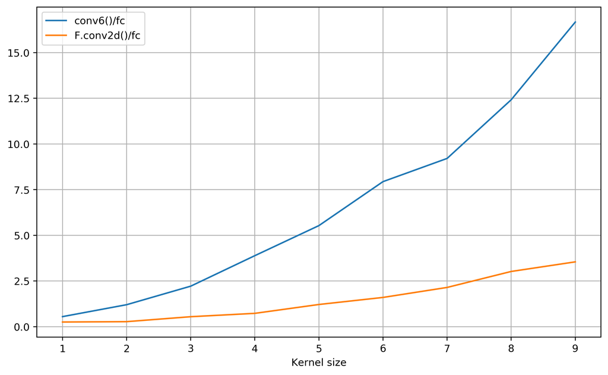

```python
plt.figure(num=None, figsize=(10, 6), dpi=350)
plt.plot(range(1, 10), convTimes/fcTimes)
plt.plot(range(1, 10), builtinConvTimes/fcTimes)
plt.legend(["conv6()/fc", "F.conv2d()/fc"]); plt.grid(True); plt.xlabel("Kernel size"); pass
```

So, as the kernel grows larger, it does seem to take $O(n^2)$ more time to complete, in both `conv6()` and `F.conv2d()`. Let's end this post by realizing that being limited in time kinda sucks, as you have to wait a long time for it to finish, but at least it's better than being limited in space, where you can't do the operation at all. That and with other nice properties like preserving a sense of 2d in an image makes convolution layers all the rage right now.